# Escherichia coli Data Exploration in the Upper Santa Cruz River

## Combine the ecoli, USGS, and environmental variable data.

USGS - discharge and stage data ClimateAnalyzer (ClimateAnalyzer.org) - Tmax, Tmin and precip NOAA (https://psl.noaa.gov/enso/climaterisks/years/top24enso.html) - El Nino / La Nina National Park Service Streams Monitoring Protocol (NPS.GOV/SODN) - Seasonal Data

Merge the ecoli data with the USGS (flow) data.

```r
# Ensure that this is in the correct time format. Always problematic, so this is over-coded to ensure success.
ecoli_data$DateTime2 <- as.POSIXct(format(paste(ecoli_data$DateAsDate,ecoli_data$ActivityStartTime.Time), format = '%Y-%m-%d %H:%M'), tz = tz)

ecoli_data$DateTime2 <-
round_date(as.POSIXct(ecoli_data$DateTime2), "15 minutes")


data_Merge<- left_join(ecoli_data,
                          USGS_Standardized, by = c("DateTime2"))

data_Merge %>%
  count(is.na(Discharge_CFS))
```

| is.na(Discharge_CFS) | n |
| --- | --- |
| FALSE | 1139 |
| TRUE | 75 |

```r
# 75 records are still without discharge. this is the one I care the most about.
```

Remove raw data, now merged

```r
rm(USGS_Standardized, ecoli_data)
```

Remove the nulls from the merge. Total remaining after removoal is 1139 on 9/13/22.

```r
data_Merge2 <- data_Merge %>%
  filter(!is.na(Discharge_CFS))
```

Look at what the data currently looks like.

The red line is 235, the single sample maximum for full body contact in Arizona.

The blue dotted line indicates the state standard for an average of three+ measurements (full body contact in Arizona). It is not technically applicable here, but gives a baseline. It may be used to flag “Concerning-but-not-technically-bad” levels of E. coli.

The green line is 575, the single sampe maximum for partial body contact in Arizona.

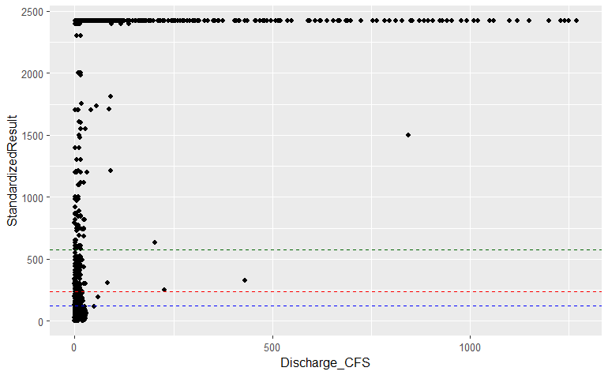

```r
data_Merge2 %>%
  ggplot(aes(x=Discharge_CFS, y=StandardizedResult)) +
  geom_point()+
  geom_hline(yintercept=126, linetype="dashed",
                color = "blue", size=0.2) +
  geom_hline(yintercept=235, linetype="dashed",
                color = "red", size=0.2)+
  geom_hline(yintercept=575, linetype="dashed",
                color = "dark green", size=0.2)
```

Now I want to see what it looks like without the outlying discharge values.

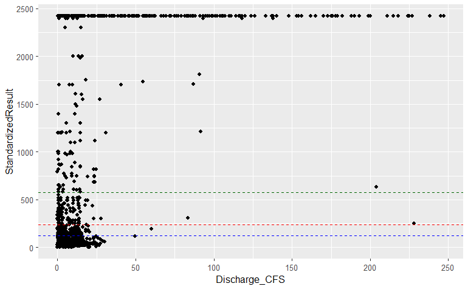

```r
data_Merge2 %>%
  filter(Discharge_CFS < 250) %>%
  ggplot(aes(x=Discharge_CFS, y=StandardizedResult)) +
  geom_point() +
  geom_hline(yintercept=126, linetype="dashed",
                color = "blue", size=0.2) +
  geom_hline(yintercept=235, linetype="dashed",
                color = "red", size=0.2)+
  geom_hline(yintercept=575, linetype="dashed",
                color = "dark green", size=0.2)
```

Now I want to see what it looks like without the outlying discharge values. None of these graphs appear to have a random distribution, but it is muddied.

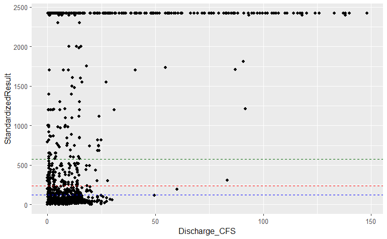

```r
data_Merge2 %>%
  filter(Discharge_CFS < 150) %>%
  ggplot(aes(x=Discharge_CFS, y=StandardizedResult)) +
  geom_point() +
  geom_hline(yintercept=126, linetype="dashed",
                color = "blue", size=0.2) +
  geom_hline(yintercept=235, linetype="dashed",
                color = "red", size=0.2)+
  geom_hline(yintercept=575, linetype="dashed",
                color = "dark green", size=0.2)
```

Let’s add some air temperature up in here, up in here.

```r
# Read in file
Rawclimate <- "Data/Raw/ClimateAnalyzer_DailySummaryStats_Raw.csv"
DailyClimate <- read.csv(Rawclimate, skip = 3)
DailyClimate <- head(DailyClimate, - 1)

# Variable no longer needed.
rm(Rawclimate)
```

What about the sum of previous three-days precipitation

```r
# Use lag to include only previous data so that forecasting may occur on a more timely basis.Min temp is not published until the day after.
DailyClimate$Previous3Precip <-  lag(rollsumr(DailyClimate$Precipitation..in., k = 3, fill = NA))
DailyClimate$Previous7Precip <-  lag(rollsumr(DailyClimate$Precipitation..in., k = 7, fill = NA))
DailyClimate$Previous30Precip <-  lag(rollsumr(DailyClimate$Precipitation..in., k = 30, fill = NA))
```

Lag Tmax an Tmin

```r
# Use the previous day's Tmin due to data posting interval. This may be used for future forecasting.
DailyClimate$PreviousTmin <- lag(DailyClimate$Tmin..F.,2)
# Use the previous day's Tmin due to data posting interval. This may be used for future forecasting.
DailyClimate$PreviousTmax <- lag(DailyClimate$Tmax..F.)
```

Fix the date.

```r
DailyClimate$DateAsDate <- str_sub(DailyClimate$Date,-10,-1)
DailyClimate$DateAsDate <-as.POSIXct(DailyClimate$DateAsDate, format = "%m/%d/%Y", tz = tz)
```

Merge together with other data

```r
data_Merge2$DateAsDate <-as.POSIXct(data_Merge2$DateAsDate, format = "%Y-%m-%d", tz = tz)


data_Merge2<- left_join(data_Merge2,
                          DailyClimate, by = c("DateAsDate"))


data_Merge2 %>%
  filter(is.nan(PreviousTmax))
```

| DateAsDate | ActivityStartTime.Time | MonitoringLocationIdentifier | ActivityConductingOrganizationText | DistFromSonoita | QuantificationLimit | StandardizedResult | DateTime2 | date | USGS_Staff | Discharge_cd | tz_cd | DailyFlowCount | Discharge_CFS | DisDif | DisDif2 | Stage | Date | Precipitation..in. | Tmax..F. | Tmin..F. | Snow.Depth.On.Ground..Inches. | X | Previous3Precip | Previous7Precip | Previous30Precip | PreviousTmin | PreviousTmax |
| --- | --- | --- | --- | --- | --- | --- | --- | --- | --- | --- | --- | --- | --- | --- | --- | --- | --- | --- | --- | --- | --- | --- | --- | --- | --- | --- | --- |
| 2016-08-22 | 09:45:00 | AZDEQ_SW-146 | ARIZONA DEPT OF ENVIRONMENTAL QUALITY | 13200 | Value | 2419.6 | 2016-08-22 09:45:00 | 2016-08-22 | 19.67 | A | America/Phoenix | 96 | 15.20 | -0.90 | 0 | 4 | 08/22/2016 | 0.20 | NaN | NaN | NaN | NA | 0.12 | 0.12 | 4.96 | NaN | NaN |
| 2016-08-22 | 09:45:00 | AZDEQ_SW-146 | ARIZONA DEPT OF ENVIRONMENTAL QUALITY | 13200 | Value | 2419.6 | 2016-08-22 09:45:00 | 2016-08-22 | 19.67 | A | America/Phoenix | 96 | 15.20 | -0.90 | 0 | 4 | 08/22/2016 | 0.20 | NaN | NaN | NaN | NA | 0.12 | 0.12 | 4.96 | NaN | NaN |
| 2016-08-17 | 10:20:00 | AZDEQ_SW-146 | INTERNATIONAL BOUNDARY AND WATER COMMISSION | 13200 | Value | 648.8 | 2016-08-17 10:15:00 | 2016-08-17 | 19.32 | A | America/Phoenix | 96 | 1.13 | 0.00 | 0 | 1 | 08/17/2016 | 0.00 | NaN | NaN | NaN | NA | 0.00 | 0.60 | 5.29 | NaN | NaN |
| 2019-09-23 | 08:30:00 | AZDEQ_SW-146 | VOLUNTEER GROUPS | 13200 | Value | 2419.6 | 2019-09-23 08:30:00 | 2019-09-23 | 19.70 | A e | America/Phoenix | 96 | 11.20 | 0.70 | 1 | 2 | 09/23/2019 | 0.00 | NaN | NaN | 0 | NA | 0.00 | 0.78 | 4.39 | NaN | NaN |
| 2022-02-02 | 11:45:00 | AZDEQ_SW-527 | VOLUNTEER GROUPS | 13200 | Value | 23.1 | 2022-02-02 11:45:00 | 2022-02-02 | 20.02 | P | America/Phoenix | 96 | 16.10 | 0.00 | 0 | 4 | 02/02/2022 | 0.00 | NaN | NaN | 0 | NA | 0.00 | 0.00 | 0.02 | 33 | NaN |
| 2019-10-01 | 03:15:00 | AZDEQ_SW-527 | ARIZONA DEPT OF ENVIRONMENTAL QUALITY | 13200 | Value | 1553.1 | 2019-10-01 03:15:00 | 2019-10-01 | 19.76 | A | America/Phoenix | 85 | 16.00 | -1.90 | 0 | 4 | 10/01/2019 | 0.00 | NaN | NaN | 0 | NA | 0.00 | 1.07 | 1.85 | NaN | NaN |
| 2020-05-04 | 03:14:00 | AZDEQ_SW-527 | VOLUNTEER GROUPS | 13200 | Value | 117.8 | 2020-05-04 03:15:00 | 2020-05-04 | 19.88 | A | America/Phoenix | 89 | 9.76 | 0.63 | 1 | 2 | 05/04/2020 | 0.00 | 90 | 47 | 0 | NA | 0.00 | 0.00 | 0.24 | 50 | NaN |
| 2022-08-05 | 11:34:00 | AZDEQ_SW-527 | VOLUNTEER GROUPS | 13200 | Present Above Quantification Limit | 2419.6 | 2022-08-05 11:30:00 | 2022-08-05 | 20.10 | P | America/Phoenix | 96 | 43.30 | -1.00 | 0 | 4 | 08/05/2022 | NaN | NaN | NaN | NaN | NA | NaN | NaN | NaN | NaN | NaN |
| 2016-08-17 | 09:30:00 | AZDEQ_SW-965 | INTERNATIONAL BOUNDARY AND WATER COMMISSION | 1700 | Value | 260.3 | 2016-08-17 09:30:00 | 2016-08-17 | 19.32 | A | America/Phoenix | 96 | 1.13 | 0.00 | 0 | 1 | 08/17/2016 | 0.00 | NaN | NaN | NaN | NA | 0.00 | 0.60 | 5.29 | NaN | NaN |
| 2019-09-23 | 09:00:00 | AZDEQ_SW-965 | VOLUNTEER GROUPS | 1700 | Value | 2419.6 | 2019-09-23 09:00:00 | 2019-09-23 | 19.74 | A e | America/Phoenix | 96 | 14.40 | 2.40 | 1 | 2 | 09/23/2019 | 0.00 | NaN | NaN | 0 | NA | 0.00 | 0.78 | 4.39 | NaN | NaN |

[output cut: 95 more lines]

```r
NA
```

Graph again This isn’t as great as I thought it would be. Google says temps of 39-113°F are survivable for e. coli and ideal is 98.6°F. THe majority of the samples are survivable.

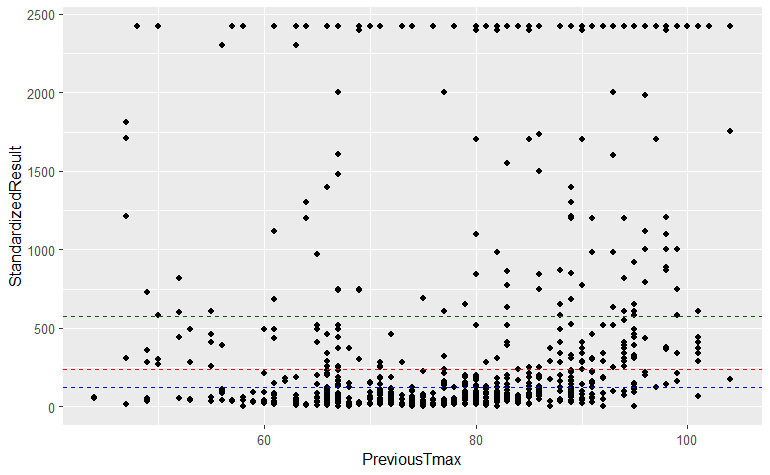

```r
data_Merge2 %>%
  filter(!is.nan(PreviousTmax)) %>%
  ggplot(aes(x=PreviousTmax, y=StandardizedResult)) +
  geom_point() +
  geom_hline(yintercept=126, linetype="dashed",
                color = "blue", size=0.2) +
  geom_hline(yintercept=235, linetype="dashed",
                color = "red", size=0.2)+
  geom_hline(yintercept=575, linetype="dashed",
                color = "dark green", size=0.2)
```

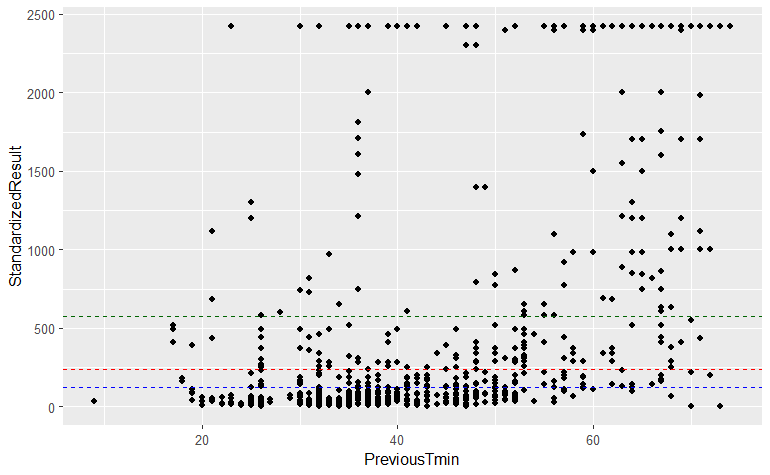

```r
data_Merge2 %>%
  filter(!is.nan(PreviousTmin)) %>%
  ggplot(aes(x=PreviousTmin, y=StandardizedResult)) +
  geom_point() +
  geom_hline(yintercept=126, linetype="dashed",
                color = "blue", size=0.2) +
  geom_hline(yintercept=235, linetype="dashed",
                color = "red", size=0.2)+
  geom_hline(yintercept=575, linetype="dashed",
                color = "dark green", size=0.2)
```

There is probably a better source for precipication, but I’d like to take a look at it. It may be correlated to flow. I’ll have to check this later.

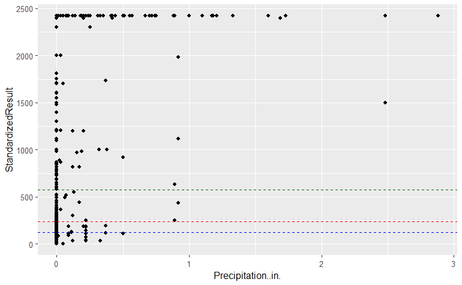

```r
data_Merge2 %>%
  filter(!is.nan(Precipitation..in.)) %>%
  ggplot(aes(x=Precipitation..in., y=StandardizedResult)) +
  geom_point() +
  geom_hline(yintercept=126, linetype="dashed",
                color = "blue", size=0.2) +
  geom_hline(yintercept=235, linetype="dashed",
                color = "red", size=0.2)+
  geom_hline(yintercept=575, linetype="dashed",
                color = "dark green", size=0.2)
```

This creates a rolling minimum value at different intervals. As precipitation data is currently questionable, I would like to shift to using minimum temperature instead (11/4/2022). According to correlation plots run previously, tMin is nearly as correlated as previous 30 precip.